# Is Saturated Fat Unhealthy?

Meta-analyses of Randomized Controlled Trials

John | The John & Calvin Podcast

## Saturated Fat

Is saturated fat bad for you?

Does reducing dietary saturated fat reduce the occurrence of **heart attacks, cardiovascular death, or death by any cause**?

What do the latest meta-analyses on RCTs say?

- April 2025 meta-analysis said “no”.
- December 2025 meta-analysis said “yes…but it depends”.

So which is it?

## Meta-analysis

- A method of combining evidence from similar studies
- using quantitative methods (statistical techniques)
- More precise conclusion (higher statistical power than a single study)
- Studies should be relatively similar in design and outcome
- The top of the [evidence hierarchy](https://guides.library.ucdavis.edu/systematic-reviews/levels-of-evidence)

**Randomized Controlled Trial**:

- a study that randomly assigns people to different groups so underlying differences are balanced
- helps isolate whether an intervention caused a specific outcome

#### MAIN EVENT: YAMADA vs. STEEN 2025

**Yamada et al. (2025)**

- Included 9 RCTs
- Found no significant reduction in:
  - all-cause mortality, cardiovascular mortality, myocardial infarction, coronary artery events
- Stroke could not be meaningfully evaluated because too few stroke events were reported.
- Most included trials were secondary prevention studies, and very few participants were on statins.

“The findings indicate that a reduction in saturated fats **cannot be recommended** at present to prevent cardiovascular diseases and mortality.”

**Steen et al. (2025)**

- Included 17 RCTs total (fewer per outcome/intervention)
- Overall, found no significant reduction in:
  - all-cause mortality, cardiovascular mortality, nonfatal myocardial infarction, stroke
- However, replacement by PUFA for nonfatal MI -> significant reduction
- Relative risks were translated into 5-year absolute risk differences by baseline cardiovascular risk.
  - Low-risk groups: estimated absolute benefit below their threshold for importance.
  - High-risk groups: estimated absolute benefit above their threshold for importance.

“Among persons at high cardiovascular risk, low- to moderate certainty evidence was found for important reductions in mortality and major cardiovascular events, particularly for MI, with respect to replacing saturated fat with polyunsaturated fat.

### The Forest Plot

*from Yamada et al. (2025), Figure 3. Forest plots of saturated fatty acid reduction trials on all-cause mortality.*

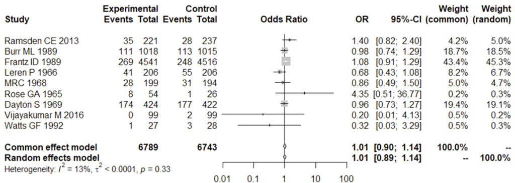

*Heterogeneity* (I²): Statistical heterogeneity = the percentage of the total observed disagreement between study results that is not easily explained by random sampling error alone. Higher = more disagreement between studies

- I² asks how much the study results differ from each other beyond what would be expected from random sampling error alone.
  1. Calculate how far each study’s estimate is from the pooled estimate
  2. Weight those differences by each study’s precision, then add them up.
  3. Check whether the studies disagree more than would be expected from ordinary random sampling error, given each study’s own margin of error, assuming they were all estimating the same true effect.
  4. I² expresses the excess disagreement as a percentage of the total observed disagreement.

It is not Clinical/methodological heterogeneity (differences/variation in study population, interventions, outcomes definitions…etc), although you may see that reflected in it.

#### Yamada Audit: Reporting, Endpoints, and Interpretation Risk

- Yamada reports Risk Ratio results in the abstract, but Odds Ratios in the paper and charts. Labeling error.
- Risk Ratio and Odds Ratio are similar but not identical.
  - RR compares probabilities, OR compares odds (less intuitive)
- Show OR/RR charts, Note for Fig 4 and 5, LOO sensitivity analysis

**Myocardial Infarction and Any Coronary Artery Event (Fig 4 and 5)**

- Same Burr/DART study counts in Figure 4, “myocardial infarction,” and Figure 5, “any coronary artery event”
- In the original Burr/DART table, those counts are **132 vs 144** for **IHD events**, not clearly MI
  - table separately reports non-fatal MI = **35 vs 47**
- Burr defines IHD events = `IHD deaths + non-fatal MI`
- Yamada appears to use Burr’s broader IHD-event counts for the MI outcome
  - this would only match `fatal + non-fatal MI` if every single IHD death was a fatal MI
  - theoretically possible, but unlikely and the choice is not justified by Yamada
- Burr has large weight and Yamada’s pooled MI result is **borderline**
- This endpoint choice could materially affect the **overall MI conclusion and the paper’s conclusion**

“any coronary artery event” could reasonably use Burr’s IHD-event count, but “myocardial infarction” should not also use that same count. Burr does not report the fatal-plus-nonfatal MI count.

### Steen Audit: Display Typos

- Steen Figure 3 appears to contain two typos in the displayed event/total columns
- Moy et al. 2001: printed as 2/177 vs 1/118
  - supplement shows 2/117 vs 1/118
- Veterans Admin 1969: printed as 13/424 vs 21/427
  - supplement and source trial support 13/424 vs 21/422
- published RR column and pooled RR are correct
  - calculations do not reflect the typos in the table)
- Show RR charts, LOO sensitivity analysis

### Steen Audit: Absolute Risk Reduction

Steen reports absolute risk reductions by baseline cardiovascular risk group.

- “Among persons at high cardiovascular risk…important reductions in mortality…”

RR tells us the *relative* effect, but ARR depends on the patient’s starting risk:

ARR = baseline risk × (1 − RR)

- Pooled RR from diet trials: **0.86** for nonfatal MI
- High-risk baseline risk from CTT* : **85 per 1000 over 5 years**
- Treated risk: **85 × 0.86 = 73 per 1000**
- ARR: **85 − 73 = 12 fewer nonfatal MIs per 1000 over 5 years**
- Treated risk = 8.5% × 0.86 = 7.31%
- ARR = 8.5% − 7.31% = 1.19 percentage points

Reasonable, but the ARR is modeled, not directly observed. It assumes:

- Applicability depends on whether the person has a similar underlying 5-year MI risk to the CTT high-risk group
- The same RR applies across baseline-risk groups
- Five-year risk is an appropriate time frame (could be higher for longer)

CTT = **Cholesterol Treatment Trialists’ Collaboration**, a large meta-analysis group that pooled individual/statin trial data and reported cardiovascular event risks by baseline risk category.

### Yamada vs. Steen Overall Comparison

- **Yamada’s conclusion is stronger than its analysis supports**
  - reports RR in the abstract but OR in the paper and figures
  - MI endpoint is poorly defined and includes the Burr/DART endpoint problem
  - treats borderline “CI crosses 1.0” as supporting a broad “cannot be recommended”
  - supplement provides little beyond search strategy
- **Steen is more rigorous and decision-oriented**
  - separates results by replacement nutrient, especially PUFA vs other replacements
  - translates relative effects into absolute risk differences
  - treats borderline “CI doesn’t cross 1.0” more cautiously (“low/moderate certainty”)
  - provides detailed supplements, subgroup analyses, and sensitivity checks
- **Main difference**
  - Steen’s conclusion is cautious and risk-stratified
  - Yamada’s conclusion is stronger than the evidence supports
- **Bottom line**
  - The strongest signal is for PUFA replacement reducing nonfatal MI
  - The RCT evidence is not decisive
  - Borderline CIs should not be overinterpreted in either direction
  - Effects should be interpreted within the trial durations and adherence actually achieved

### Summary of Overall Pooled Estimates

Possible Interpretations:

**A Signal Increasingly Diluted**

- Assume lowering saturated fat has some real effect
- And that effect would works through cardiovascular disease
- We would expect to see it first in specific cardiovascular outcomes, like MI or non-fatal MI
- We would expect it less clearly in cardiovascular death
- And even less clearly in all-cause mortality, which is a more diluted endpoint
- In shorter, noisier trials, all-cause mortality or CVD mortality may show little or no separation between control and experimental, but might in longer trials.

**Take “No Effect” Results at Face Value**

- The pooled results may be closer to the real effect
- Any real effect on hard endpoints may be small or absent
- Differences in MI or CVD outcomes may reflect chance or unstable study differences
- Or any true effect may be highly context-dependent, rather than general

### Relative Risk vs Absolute Risk Reduction

- **RR and ARR answer different questions.**
  - **RR:** what was the proportional difference between groups?
  - **ARR:** what was the absolute difference between groups over a specific time period?
- **RR can be taken out of context but so can ARR.**
  - RR = 0.85 means the event rate was 15% lower, but that could mean AR: 30% → 25.5%, or 3% → 2.55%.
  - ARR: “Only 1.5 percentage point reduction” is incomplete unless we know:
    - over how many years, in what baseline-risk population (and all other caveats from source trials)
- Neither measure is self-interpreting or assumption-free.
  - RR without baseline risk can overstate practical importance.
  - ARR without time horizon, population risk, and scale can understate practical or public health importance.
    - A 5-year ARR is not the same as a 10-year, 30-year, or lifetime ARR.
    - probably not a safe assumption that it increases linearly over time.
    - which population is the baseline risk from
- The Risk Ratio is incomplete without context
- The Absolute Risk Reduction is incomplete without context
- Where possible, both should be reported with context.

### Report the ARR!

- RCT metrics: RR, RRR, ARR, NNT
- Meta-analyses: usually emphasize pooled RR / OR / HR
- ARR is less often pooled directly because:
  - ARR depends strongly on the baseline risk in the control group
  - The same RR can imply very different ARRs in low- vs. high-risk populations
  - Trial populations often differ in baseline risk, making a single pooled ARR harder to interpret
- Common meta-analysis approach:
  - Pool the relative effect, such as RR or OR and apply it to a clinically relevant baseline risk
  - Estimate ARR and NNT from that baseline risk
- Steen used another meta-analysis for the baseline risks (CTT, a large 2012 statin-trial meta-analysis)
- CTT supplied 5-year baseline risks for 4 groups from low to high

**There are legitimate statistical reasons that relative measures like RR, OR, and HR are often emphasized in meta-analyses.**

**There are legitimate interpretive concerns that relative measures can exaggerate the practical significance of the intervention, especially for individuals at low baseline risk.**

**There are legitimate interpretive reasons to present absolute measures like ARR, especially because they show the practical size of the effect in a given population.**

**There are legitimate interpretive concerns that absolute measures can minimize a real effect when events are low, follow-up is short, or outcomes are rare.**

## Some Context

[2012 JAMA article on Lifetime Risk and Years Lived Free of Total Cardiovascular Disease](https://jamanetwork.com/journals/jama/fullarticle/1389613)

- Pooled survival analysis from **5 NHLBI-funded community cohorts**
  - **Framingham Heart Study, Framingham Offspring Study, ARIC, Chicago Heart Association Detection Project, and Cardiovascular Health Study**
- Up to **905,115 person-years** of follow-up, **1964–2008**
- Participants were **free of CVD at baseline**
- Community-based U.S. cohorts, not a nationally representative sample
- Likely somewhat healthier/selected than the general U.S. population

“At an index age of 45 years, overall lifetime risk for total CVD was **60.3%** (95% CI, 59.3%-61.2%) for men and **55.6%** (95% CI, 54.5%-56.7%) for women.”

total CVD events = fatal and nonfatal coronary heart disease, all forms of stroke, congestive heart failure, and other CVD deaths; USA data

- baseline lifetime risk of total CVD event:
  - **male: 60%**
  - **female: 56%**
- total CVD event: broader than the outcomes in the saturated-fat meta-analysis.

### Meta-analyses on RCTs: SFA Reduction

| Year | Review | Core frame | Result | Benefit? |
| --- | --- | --- | --- | --- |
| 2010 | [**Mozaffarian et al.**](https://pubmed.ncbi.nlm.nih.gov/20351774/) | PUFA replacing SFA; RCT meta-analysis. | Lower CHD events when PUFA replaced SFA. | **Yes** |
| 2011 | [**Hooper et al.**](https://pubmed.ncbi.nlm.nih.gov/21735388/) | Reduced/modified fat; not SFA-only. | Lower combined CVD events; no clear all-cause or CVD mortality benefit. | **Yes** |
| 2013 | [**Ramsden et al.**](https://pubmed.ncbi.nlm.nih.gov/23386268/) | Sydney Diet Heart reanalysis + linoleic acid trial meta-analysis. | No overall CVD benefit; Sydney showed higher all-cause, CVD, and CHD mortality. | **No** |
| 2014 | [**Schwingshackl & Hoffmann**](https://pubmed.ncbi.nlm.nih.gov/24747790/) | Secondary prevention; reduced/modified fat. | No significant benefit for mortality, CVD events, or MI. | **No** |
| 2015 | [**Hooper et al.**](https://pubmed.ncbi.nlm.nih.gov/26068959/) | SFA-specific Cochrane review. | Lower combined CVD events; no clear mortality benefit. | **Yes** |
| 2017 | [**Hamley**](https://pubmed.ncbi.nlm.nih.gov/28526025/) | Replacing SFA with mostly n-6 PUFA; RCT meta-analysis. | No clear reduction in CHD events, CHD mortality, or total mortality in adequately controlled trials. | **No** |
| 2020 | [**Hooper et al.**](https://pubmed.ncbi.nlm.nih.gov/32428300/) | Updated SFA-specific Cochrane review. | Lower combined CVD events; little or no mortality benefit. | **Yes** |
| 2025 | [**Yamada et al.**](https://pubmed.ncbi.nlm.nih.gov/40416032/) | SFA-restriction RCT meta-analysis. | No significant effect on CVD mortality, all-cause mortality, MI, or coronary events. | **No** |
| 2025 | [**Steen et al.**](https://pubmed.ncbi.nlm.nih.gov/41397264/) | Risk-stratified review of reduced/modified SFA RCTs. | Little or no benefit in low-risk groups; possible benefit in high-risk groups, especially with PUFA replacement. | **Yes** |

## Lack of Consistency

**Why?**

- the underlying trials differ in intervention, comparator, replacement nutrient, population, duration, setting, and outcomes
- which trials to include and even which *version* of a trial to include
- how the intervention is defined and classified
  - reducing / replacing saturated fat, PUFA replacement, unsaturated-fat replacement, reduced / modified fat, CHO replacment
- how the replacement nutrient is defined and classified
- which outcomes are analyzed and how they are classified
  - MI, CHD death, CVD death, stroke, coronary events, all-cause mortality
- how much subgrouping to do
  - trial length, participant age, risk profile, primary / secondary prevention, dietary replacement
- how the trials are pooled and analyzed
  - fixed vs random effects, subgrouping, reanalyses, treatment of mixed interventions

## RCTs SFA Reduction / CVD

| Pub year | Start year | Trial | N | Duration | Population | Comparator | SFA change | Hard outcomes | Trans-fat issue | Major caveat |
| --- | --- | --- | --- | --- | --- | --- | --- | --- | --- | --- |
| 1965 | c.1963 | [**Rose / St Mary’s**](https://pubmed.ncbi.nlm.nih.gov/14288105/) | 80 | 1.5–1.7 y avg, 2yr study | Men with angina or post-MI | Corn oil or olive oil + fat restriction vs usual diet | NR | Limited | Unclear* | Tiny 3-arm trial; SFA not measured |
| 1966 | 1956 | [**Oslo Diet Heart / Leren**](https://pubmed.ncbi.nlm.nih.gov/5228820/) | 412 | 5 y | Men with prior MI | Low-SFA advice + soy oil/fish vs usual diet | NR | Yes | Unclear* | SFA not directly measured; soy/fish cointervention |
| 1968 | 1960 | [**MRC Soybean Oil**](https://pubmed.ncbi.nlm.nih.gov/4175085/) | 393 | 3.8 y mean | Men after first MI | Soybean oil + fat restriction vs usual diet | NR | Limited | Unclear* | Soy-oil supplement trial; SFA not measured |
| 1969 | 1959 | [**LA Vet Admin / Dayton**](https://www.ahajournals.org/doi/10.1161/01.CIR.40.1S2.II-1) | 846 | max 8y, unclear avg | Semi-institutionalized men, mixed CHD status | Whole diet replacing about two-thirds of SFA with unsaturated fat | -10.2% | Yes | Probable | Partial feeding / institutional setting |
| 1978 | 1973 | [**Oxford Retinopathy**](https://pubmed.ncbi.nlm.nih.gov/629924/) | 249 | 9.3 y mean | Newly diagnosed type 2 diabetes | Lower-fat / higher-PUFA diabetic diet vs average diabetic diet | -9.7% | No | Unclear* | Retinopathy trial; deaths not cleanly by arm |
| 1978 | 1966 | [**Sydney Diet Heart Study**](https://pubmed.ncbi.nlm.nih.gov/727035/) | 458 | 4.3 y mean | Men with prior MI | Safflower oil + safflower margarine vs usual diet | -3.7% | Yes | Probable | LA-specific substitution trial; margarine-era intervention |
| 1979 | 1959 | [**Finnish Mental Hospital (Men)**](https://pubmed.ncbi.nlm.nih.gov/5652949/) | ~461 | 6 y per arm | Institutionalized middle-aged men without CHD | Hospital SCL diet vs normal hospital diet | NR | Limited | Probable | Non-randomized cluster crossover; open enrollment |
| 1979 | 1973 | [**Houtsmuller**](https://pubmed.ncbi.nlm.nih.gov/7342100/) | 102 | Up to 6 y | Newly diagnosed diabetes | High-linoleic modified-fat diet vs usual diabetic diet | NR | Limited | Unclear* | Retinopathy/diabetes focus; SFA not reported |
| 1983 | 1959 | [**Finnish Mental Hospital (Women)**](https://pubmed.ncbi.nlm.nih.gov/6840954/) | ~357 | 6 y per arm | Institutionalized middle-aged women without CHD | Hospital SCL diet vs normal hospital diet | NR | Limited | Probable | Non-randomized cluster crossover; open enrollment |
| 1989 | 1983 | [**DART / Burr**](https://pubmed.ncbi.nlm.nih.gov/2571009/) | 2033 | 2 y | Men recovering from MI | Lower-fat / higher-P:S advice vs usual advice | -4.0% | Yes | Unclear* | Factorial trial; only 2 years |
| 1989 | 1968 | [**Minnesota Coronary / Frantz**](https://pubmed.ncbi.nlm.nih.gov/2643423/) | 9057 | Avg 1 y, max 4.5 y | Institutionalized men and women; mixed CHD status | Corn oil + corn-oil margarine vs control diet | -9.1% | Yes | Probable | Open enrollment; average exposure short |
| 1992 | 1988 | [**STARS / Watts**](https://pubmed.ncbi.nlm.nih.gov/1347091/) | ~60 | 3 y | Men with established CHD | Low-SFA diet vs usual care | -7.0% | Sparse | Unclear | Tiny trial; angiography-focused |
| 1994 | c.1992 | [**Black**](https://pubmed.ncbi.nlm.nih.gov/8145782/) | 133 | 2 y | People with non-melanoma skin cancer | Low-fat diet vs usual diet | -6.2% | Sparse | Low | Not a CVD trial |
| 1997 | 1987 | [**Simon**](https://pubmed.ncbi.nlm.nih.gov/9121940/) | 194 | 2 y | Women at high breast-cancer risk | Low-fat diet vs usual diet | -6.1% | No | Low | Feasibility / cancer trial; deaths not clearly by arm |
| 2001 | 1991 | [**Moy**](https://pubmed.ncbi.nlm.nih.gov/11832672/) | 235 | 2 y | Siblings of early-CHD patients with risk factors | nurse dietary counseling vs usual physician care | -2.9% | Sparse | Low | No deaths; family-risk trial |
| 2004 | 1988 | [**Ley**](https://pubmed.ncbi.nlm.nih.gov/14739050/) | 176 | 4.1 y mean | Impaired glucose tolerance / high-normal glucose | Reduced-fat program vs usual diet | -3.4% | Sparse | Low | Prediabetes trial; not CVD-primary |
| 2006 | 1993 | [**WHI Dietary Modification**](https://pubmed.ncbi.nlm.nih.gov/16467234/) | 48,835 | 8.1 y mean | Postmenopausal women, with and without baseline CVD | Low-fat pattern with fruit/veg emphasis vs usual diet | -2.9% | Yes | Low | Mostly low-fat / carb-replacement trial, not a clean SFA test |
| 2006 | 1994 | [**WINS**](https://pubmed.ncbi.nlm.nih.gov/17179478/) | 2437 | 5 y | Women with resected breast cancer | Low-fat counseling vs minimal counseling | -3.4% | Sparse | Low | Not a CVD trial; no combined CVD endpoint |
| 2016 | 2009 | [**Amrita / Vijayakumar**](https://pubmed.ncbi.nlm.nih.gov/27543472/) | 200 | 2 y | Patients with stable CAD | Sunflower oil vs coconut oil | NR | Sparse | Low | Oil-vs-oil trial under standard medical care; not a real SFA-reduction trial |

## Yamada 2025 Trials

| Pub year | Start year | Trial | N | Duration | Population | Comparator | SFA change | Hard outcomes | Trans-fat issue | Major caveat |
| --- | --- | --- | --- | --- | --- | --- | --- | --- | --- | --- |
| 1965 | c.1963 | [**Rose / St Mary’s**](https://pubmed.ncbi.nlm.nih.gov/14288105/) | 80 | 1.5–1.7 y avg, 2yr study | Men with angina or post-MI | Corn oil or olive oil + fat restriction vs usual diet | NR | Limited | Unclear* | Tiny 3-arm trial; SFA not measured |
| 1966 | 1956 | [**Oslo Diet Heart / Leren**](https://pubmed.ncbi.nlm.nih.gov/5228820/) | 412 | 5 y | Men with prior MI | Low-SFA advice + soy oil/fish vs usual diet | NR | Yes | Unclear* | SFA not directly measured; soy oil/fish cointervention |
| 1968 | 1960 | [**MRC Soybean Oil**](https://pubmed.ncbi.nlm.nih.gov/4175085/) | 393 | 3.8 y mean | Men after first MI | Soybean oil + fat restriction vs usual diet | NR | Limited | Unclear* | Soy-oil supplement trial; SFA not measured |
| 1969 | 1959 | [**LA Vet Admin / Dayton**](https://www.ahajournals.org/doi/10.1161/01.CIR.40.1S2.II-1) | 846 | max 8y, unclear avg | Semi-institutionalized men, mixed CHD status | Whole diet replacing about two-thirds of SFA with unsaturated fat | -10.2% | Yes | Probable | Partial feeding / institutional setting |
| 2013 | 1966 | [**Sydney Diet Heart Study** (Ramsden)](https://pubmed.ncbi.nlm.nih.gov/23386268/) | 458 | 4.3 y mean | Men with prior MI | Safflower oil + safflower margarine vs usual diet | -3.7% | Yes | Probable | LA-specific substitution trial; margarine-era intervention |
| 1989 | 1983 | [**DART / Burr**](https://pubmed.ncbi.nlm.nih.gov/2571009/) | 2033 | 2 y | Men recovering from MI | Lower-fat / higher-P:S advice vs usual advice | -4.0% | Yes | Unclear | Factorial trial; only 2 years |
| 1989 | 1968 | [**Minnesota Coronary / Frantz**](https://pubmed.ncbi.nlm.nih.gov/2643423/) | 9057 | Avg 1 y, max 4.5 y | Institutionalized men and women; mixed CHD status | Corn oil + corn-oil margarine vs control diet | -9.1% | Yes | Probable | Open enrollment; average exposure short |
| 1992 | 1988 | [**STARS / Watts**](https://pubmed.ncbi.nlm.nih.gov/1347091/) | ~60 | 3 y | Men with established CHD | Low-SFA diet vs usual care | -7.0% | Sparse | Unclear | Tiny trial; angiography-focused |
| 2016 | 2009 | [**Amrita / Vijayakumar**](https://pubmed.ncbi.nlm.nih.gov/27543472/) | 200 | 2 y | Patients with stable CAD | Sunflower oil vs coconut oil | NR | Sparse | Low | Oil-vs-oil trial; short; no CVD endpoints |

Used Ramsden re-evaluation of Sydney study

## Steen 2025 Trials

| Pub year | Start year | Trial | N | Duration | Population | Comparator | SFA change | Hard outcomes | Trans-fat issue | Major caveat |
| --- | --- | --- | --- | --- | --- | --- | --- | --- | --- | --- |
| 1965 | c.1963 | [**Rose / St Mary’s (corn oil)**](https://pubmed.ncbi.nlm.nih.gov/14288105/) | 54 | 1.5–1.7 y avg, 2yr study | Men with angina or post-MI | Corn oil + fat restriction vs usual diet | NR | Limited | Unclear* | Tiny 3-arm trial; SFA not measured |
| 1965 | c.1963 | [**Rose / St Mary’s (olive oil)**](https://pubmed.ncbi.nlm.nih.gov/14288105/) | 52 | 1.5–1.7 y avg, 2yr study | Men with angina or post-MI | Olive oil + fat restriction vs usual diet | NR | Yes | Unclear* | Tiny 3-arm trial; SFA not measured |
| 1966 | 1956 | [**Oslo Diet Heart / Leren**](https://pubmed.ncbi.nlm.nih.gov/5228820/) | 412 | 5 y | Men with prior MI | Low-SFA advice + soy oil/fish vs usual diet | NR | Yes | Unclear* | SFA not directly measured; soy oil/fish cointervention |
| 1968 | 1960 | [**MRC Soybean Oil**](https://pubmed.ncbi.nlm.nih.gov/4175085/) | 393 | 3.8 y mean | Men after first MI | Soybean oil + fat restriction vs usual diet | NR | Limited | Unclear* | Soy-oil supplement trial; SFA not measured |
| 1969 | 1959 | [**LA Vet Admin / Dayton**](https://www.ahajournals.org/doi/10.1161/01.CIR.40.1S2.II-1) | 846 | max 8y, unclear avg | Semi-institutionalized men, mixed CHD status | Whole diet replacing about two-thirds of SFA with unsaturated fat | -10.2% | Yes | Probable | Partial feeding / institutional setting |
| 1989 | 1983 | [**DART / Burr**](https://pubmed.ncbi.nlm.nih.gov/2571009/) | 2033 | 2 y | Men recovering from MI | Lower-fat / higher-P:S advice vs usual advice | -4.0% | Yes | Unclear* | Factorial trial; only 2 years |
| 1989 | 1968 | [**Minnesota Coronary / Frantz**](https://pubmed.ncbi.nlm.nih.gov/2643423/) | 9057 | Avg 1 y, max 4.5 y | Institutionalized men and women; mixed CHD status | Corn oil + corn-oil margarine vs control diet | -9.1% | Yes | Probable | Open enrollment; average exposure short |
| 1992 | 1988 | [**STARS / Watts**](https://pubmed.ncbi.nlm.nih.gov/1347091/) | ~60 | 3 y | Men with established CHD | Low-SFA diet vs usual care | -7.0% | Sparse | Unclear | Tiny trial; angiography-focused |
| 1994 | 1988 | [**Lyon Diet Heart**](https://pubmed.ncbi.nlm.nih.gov/9989963/) | 605 | 27 mo median | Post-MI patients | Mediterranean-type diet vs prudent Western diet | -3.4% | Yes | Low | Multifactor dietary pattern trial, not a clean SFA test, 2ndary prev. |
| 1994 | c.1992 | [**Black**](https://pubmed.ncbi.nlm.nih.gov/8145782/) | 133 | 2 y | People with non-melanoma skin cancer | Low-fat diet vs usual diet | -6.2% | Sparse | Low | Not a CVD trial |
| 2004 | 1988 | [**Ley**](https://pubmed.ncbi.nlm.nih.gov/14739050/) | 176 | 4.1 y mean | Impaired glucose tolerance / high-normal glucose | Reduced-fat program vs usual diet | -3.4% | Sparse | Low | Prediabetes trial; not CVD-primary |
| 2001 | 1991 | [**Moy**](https://pubmed.ncbi.nlm.nih.gov/11832672/) | 235 | 2 y | Siblings of early-CHD patients with risk factors | nurse dietary counseling vs usual physician care | -2.9% | Sparse | Low | No deaths; family-risk trial |
| 2006 | 1993 | [**WHI Dietary Modification**](https://pubmed.ncbi.nlm.nih.gov/16467234/) | 48,835 | 8.1 y mean | Postmenopausal women, with and without baseline CVD | Low-fat pattern with fruit/veg emphasis vs usual diet | -2.9% | Yes | Low | Mostly low-fat / carb-replacement trial, not a clean SFA test |
| 2006 | 1994 | [**WINS**](https://pubmed.ncbi.nlm.nih.gov/17179478/) | 2437 | 5 y | Women with resected breast cancer | Low-fat counseling vs minimal counseling | -3.4% | Sparse | Low | Not a CVD trial; no combined CVD endpoint |
| 1978 | 1966 | [**Sydney Diet Heart Study**](https://pubmed.ncbi.nlm.nih.gov/727035/) | 458 | 4.3 y mean | Men with prior MI | Safflower oil + safflower margarine vs usual diet | -3.7% | Yes | Probable | LA-specific substitution trial; margarine-era intervention |

Only trials contributing to hard-endpoint analyses are shown.

Split analysis by: Replace SFA by PUFA primarily or other macronutrient primarily

Used original 1978 trial label/citation for Sydney, but appears to use Ramsden-recovered cause-specific mortality.

### Ideal RCT on Saturated Fat Reduction

How to construct the RCT to answer our question?

- what exact question is being tested
- who is being studied, and how many people
- how long the trial lasts
- what replaces saturated fat
- how different the diets really are
- how tightly the diets are controlled
- how adherence is checked
- which outcomes matter most
- whether blinding is possible

### Ideal RCT on Saturated Fat Reduction

- a very large randomized trial in generally healthy adults
- long follow-up, > 10 years
- lower saturated fat in one group, higher saturated fat in the other
  - replacement nutrient clearly specified
  - diets meaningfully different in saturated fat intake
- all or nearly all food provided, with intake closely monitored
- calories kept similar between groups so the main difference is fat type, not energy intake
- other major factors kept as similar as possible between groups
- adherence measured repeatedly and objectively where possible
- primary outcomes: MI, CHD death, CVD death, all-cause mortality
- secondary outcomes: stroke, atherosclerosis, and related cardiovascular events
- measure everything we can
- The cleaner the trial, the less it looks like real life (and more unethical).
- The more realistic, the harder it is to isolate the effect of saturated fat.

## Controversial RCTs

- Minnesota Coronary Experiment
  - Ramsden re-analysis of ‘lost’ data
- Sydney Diet Heart Study
  - Ramsden re-analysis of ‘lost’ data
- Los Angeles Veterans Administration

### Minnesota

- Study published in 1989, trial began in 1968
- double blinded, parallel group, randomized controlled dietary intervention trial
- 4393 Institutionalized men and 4664 Institutionalized women (mental institutions, nursing home)
- Participants could decline to enroll or discontinue at any time.
- corn oil / corn-oil margarine vs higher-saturated-fat institutional diet; tested cholesterol, cardiovascular events, cardiovascular death, total death.
- compared the effects of a
  - 39% fat control diet (18% saturated fat, 5% polyunsaturated fat, 16% monounsaturated fat, 446 mg dietary cholesterol per day)
  - 38% fat treatment diet (9% saturated fat, 15% polyunsaturated fat, 14% monounsaturated fat, 166 mg dietary cholesterol per day)
- mean duration of time on the diets was **384 days**
- For the entire study population, no differences between the treatment and control groups were observed for cardiovascular events, cardiovascular deaths, or total mortality.

“Products that proved particularly useful were filled milk and ice cream, a whole egg substitute, soft margarine, whipped topping, filled cheese, low fat ground beef with added vegetable oil, and filled sausage products.”

### Minnesota, Problems

- Open-enrollment, single-end-time design
- trial was conducted in state mental hospitals and one nursing home
- very high turnover and short average exposure:
  - average total time on diet: 384 days; average stay: 292 days
- exposure was often **intermittent** rather than continuous:
  - subjects could leave the institution and later return
  - missed serving-line meals likely meant eating elsewhere
- diet change was not just saturated fat reduction:
  - lower saturated fat, lower dietary cholesterol, much higher PUFA
  - very high use of corn oil / corn-oil margarine in intervention diet
- initial stratification included smoking, weight, and ECG evidence of prior MI,
  - but later admissions were stratified only by age and sex
- Historical food environment (trans-fats)
- substantial variability in study diets between hospitals
- some raw data were not recovered
- delayed / incomplete reporting and recovered-data issues

### Minnesota, Ramsden re-evaluation

- team recovered study materials stored on two nine-track magnetic tapes plus paper documents
- cross-referenced discrepancies in older reporting with the Broste thesis (a Master’s thesis written in 1981).
- re-evaluated results using recovered data
- “longitudinal data for the 2355 participants who received the intervention diet for a year or more”
  - Show fig 5, the Kaplan Meier life table graphs of cumulative mortality
- Participants were followed only while in hospital, and only about a quarter of randomized participants remained in the study for a year or longer.
- “…we are not able to determine if the effects of the high linoleic acid diet varied by smoking status, pre-existing coronary heart disease, psychiatric history, or drug use.”

**Results**:

- In the ≥1-year cohort, greater cholesterol reduction was associated with higher mortality; (observational association within the trial, not the primary randomized comparison)
- “22% higher risk of death for each 30 mg/dL (0.78 mmol/L) reduction in serum cholesterol in covariate adjusted…models”

“Findings…add to growing evidence that incomplete publication has contributed to overestimation of the benefits of replacing saturated fat with vegetable oils rich in linoleic acid.”

### Minnesota, Ramsden re-evaluation

> “confounding by dietary trans fat is an **exceedingly unlikely** explanation for the lack of benefit of the intervention diet.”
- overstatement of certainty, based on many assumptions; trans fats were almost definitely in control and intervention diets, but we don’t know how much
- [“Ramsden…did not re-analyse the results of the randomise controlled trial.”](https://www.ovid.com/journals/bmjeb/abstract/10.1136/ebmed-2016-110486~dietheart-disease-hypothesis-is-unaffected-by-results-of?redirectionsource=fulltextview)
  - subgroup analysis who were on diet > 1 year, and cholesterol data at baseline / follow-up
  - after randomization, change inclusion criteria…
  - post hoc cholesterol–mortality analysis not result of RCT
- their meta-analysis used results from original paper
- inconsistencies across recovered datasets/reports
- all the problems from original

### Sydney Diet Heart Study

- Original Paper published in 1978, trial began in 1966
- secondary intervention (with recent coronary disease)
- 458 men with coronary heart disease, aged 30-59
- 2 to 7 years.
- **intervention**: safflower oil / safflower margarine **advice** vs usual diet (restrict calories if overweight);
- **outcome**: tested all-cause, cardiovascular, and CHD mortality
  - specific, high-LA safflower intervention, not just a reduce SF trial
- diets assessed by interview and/or food log three times during the first year and twice yearly thereafter
- Group P (control): saturated fatty acids contributed 13.5% and polyunsaturated fatty acids 8.9% of total calories.
- Group F (intervention): consumed a derived 9.8% of calories from saturated fatty acids and 15.1% from polyunsaturates.

### Sydney Diet Heart Study, Problems

Small, narrow population, atypical intervention with trans-fats

### Sydney, Ramsden re-evaluation

- data recovered from the original trial dataset stored on a nine-track magnetic tape
- obtained from original investigator
- median follow-up of 39 months
- recovered and reported the CVD and CHD mortality by group, which the original paper had not reported.

**Reported in original study**:

- “The **intervention group** (n=221) had **higher rates of death than controls** (n=237) (all cause 17.6% v 11.8%, hazard ratio 1.62 (95% confidence interval 1.00 to 2.64), P=0.05”

**Ramsden found and reported**:

- cardiovascular disease 17.2% v 11.0%, 1.70 (1.03 to 2.80), P=0.04
- coronary heart disease 16.3% v 10.1%, 1.74 (1.04 to 2.92), P=0.04

Ramsden (recovered data):

- showed the excess deaths were primarily cardiovascular and coronary
- cause-specific mortality by group had not been reported previously
- “incomplete” reporting…

### LA Veterans Trial

- Published in 1968/9, trial began in 1959
- 846 male veterans, aged 54-88 (mean 65.5)
- duration varied by entry (participants could enter anytime)
- The diet intervention:
  - intervention diet: total fat same, substituted vegetable unsaturated fat for two-thirds of the animal fat
  - intervention diet: about **38.4 g/day** linoleic acid and 365.4 mg/day cholesterol.
  - control diet: conventional institutional diet, about 40% of calories from fat
  - control diet: 10.0 g/day linoleic acid and 652.7 mg/day cholesterol
- Primary outcome: ischemic heart disease manifested by sudden death or myocardial infarction.
- Secondary outcomes: cerebral infarction, amputation due to peripheral atherosclerosis, ruptured aortic aneurysm, and intestinal infarction.

Main results:

- intervention diet lowered serum cholesterol
- primary endpoint was not statistically significant
- some combined endpoint analyses favored intervention diet (p=0.04), especially in younger half of the cohort
- Fatal atherosclerotic events were lower in the intervention group; total mortality was similar between groups.

### LA Veterans Trial, Problems

- Institutional trial, but only partial diet control:
  - overall adherence: **49% intervention vs 56% control**
- uneven exposure / follow-up:
  - 8-year trial, but recruitment throughout from 1959 to 1967
  - most subjects entered early, but later recruits had much shorter possible exposure
  - no clear full-cohort average time on diet reported
- More withdrawal in the intervention group:
  - total withdrawals: **117 intervention vs 58 control**; first year withdrawals: **69 vs 24**
- mixed primary / secondary prevention population:
  - pre-existing atherosclerotic complications were not exclusion criteria
- authors noted participants may have been beyond the stage where prevention was likely
- much higher linoleic acid: **38% vs 10% of fatty acids**
  - vegetable oils, filled milk, imitation ice cream, margarine, filled cheeses, and modified meats
- baseline smoking differed between groups:
  - intervention had more moderate smokers; control had more heavy smokers; significant difference: **p < 0.01**
- historical food environment: hydrogenated shortenings / margarine-era trans-fat exposure
- nonfatal event ascertainment may have been weaker when men were away from the center
- relatively small sample size for hard endpoints: 422 control / 424 intervention (regardless of withdrawals)

### LA Veterans Trial

The carcinoma issue:

- fewer fatal atherosclerotic events on the intervention diet, but a borderline excess of carcinoma deaths.
- trial authors treated that cancer signal as concerning but inconclusive
- overall: 31 carcinoma deaths in intervention group; 17 in the control group (P=0.06). Total mortality almost equal.
- Figure 14 in main study:
  - not cancer-specific curve, ‘death due to other cause’ (other than atherosclerotic complication)
  - late excess was small in absolute numbers
  - among deaths after 6 years, total excess non-atherosclerotic mortality in intervention group was 9 cases
    - 4 of those deaths were due to trauma.

[Follow-up cancer paper, from same investigators in 1971](https://pubmed.ncbi.nlm.nih.gov/4100347/)

- many cancer deaths in intervention group occurred among men who did not adhere closely to the diet
  - reduced likelihood that the polyunsaturated-oil diet itself explained the excess carcinoma mortality
- excess was only of borderline statistical significance
- post-hoc anlaysis

### LA Veterans Trial - Carcinoma deaths

| Period | Intervention | Control |
| --- | --- | --- |
| 8-year diet phase | 31 | 17 |
| 1st year after diet phase | 3 | 0 |
| 2nd year after diet phase | 4 | 10 |
| **Total** | **38** | **27** |

Same study, same underlying problems

- Even if you trust the results, about as likely to die from either diet.
- LA Veterans does not cleanly show that seed oils increased cancer death.
- LA Veterans does not cleanly show that seed oils reduce atherosclerotic death.
- And especially it doesn’t show that in either outcome for Saturated Fat.

### Limitations of each trial

| Trial | Main limitations |
| --- | --- |
| Rose / St Mary’s | Tiny 3-arm trial; mixed oil interventions; 80g oil daily dose; SFA change not reported; too short |
| Oslo Diet Heart | SFA reduction not measured; increased soy/fish; different smoking rates; hard to isolate SFA effect |
| MRC Soybean Oil | Soybean-oil supplement trial more than a whole-diet test; modest size; old post-MI setting; short |
| LA Veterans Admin | Institutional feeding trial; mixed baseline CHD status; broad oil replacement; trans-fat |
| Sydney Diet-Heart | Safflower oil/margarine trial, not generic SFA reduction; trans-fat; re-evaluation issue |
| DART / Burr | Only 2 y; advice-based factorial trial; small SFA diff; hard to isolate SFA effect; too short |
| Minnesota Coronary | Open-enrollment institutional; Heavy dropout; avg exposure ~1 y; trans-fat; re-evaluation issue; too short (avg) |
| STARS / Watts | Very small; too few hard outcomes; focused on angiography rather than clinical events; short |
| Lyon Diet Heart | Mediterranean-pattern intervention; small SFA difference; cannot isolate SFA effect; too short |
| Black | Not designed as a heart-disease trial; very small; too few cardiovascular events; too short |
| Ley | Not designed as a heart-disease trial; modest size; small SFA difference |
| Moy | Short; small; small SFA difference; no deaths |
| WHI Diet Modification | Mostly tested a lower-fat, higher-carb diet pattern; small SFA difference; weak test of SFA |
| Amrita / Vijayakumar | Coconut-oil vs sunflower-oil comparison; all on statins; no clinical CVD endpoint; too short |

### Overall Problems with the RCTs

- short duration / short actual exposure
- high dropout, turnover, or intermittent exposure
- small number of participants
- institutional or otherwise unusual settings
- limited, inconsistent or unknown saturated fat reduction
- poor control and tracking of the actual diet
- no, few, or sparse hard outcomes
- trans-fat / historical diet environment
- many and varied potential confounders
- trials are often pooled as if they test the same exposure and outcomes, but they do not
  - varied outcomes and varied interventions (some extreme)
  - inconsistent endpoint definitions and ascertainment, especially for nonfatal events
  - different comparators, replacement nutrients, and co-interventions
  - diet changes were often multi-component, not SFA-specific

However, these trials are not useless.

- they show how difficult and messy long-term dietary RCTs really are
- some outcomes in these trials may be more informative than the sparse hard endpoints
- ambitious and carefully designed, even if they could not overcome the practical limits
- they reveal recurring problems in dietary RCTs that are easy to miss in theory
- they help show the limits of what diet RCTs can realistically test

### Overconfidence from CI Precision

- CI for a study’s RR is based on the event counts and the **number of people in each group**.
- If the full randomized cohort is used and a trial has high turnover / dropout rate or short exposure, the CI can appear more statistically precise than warranted
- In a meta-analysis, that same tight CI can also give the trial more weight.
  - so the trial may appear **too precise on its own** and **overweighted in the pooled estimate**

**Minnesota Example**:

- Described as a **4.5-year trial**, with **4541 intervention vs 4516 control**
- but open enrollment + high turnover + intermittent exposure meant much shorter avg exposure of 384 days
- Most meta-analyses use the **full randomized cohort counts** to calculate the CI
- This gives Minnesota tight CI and a high weight in a meta-analysis
- May overstate precision if read as evidence from a **4.5-year saturated-fat-reduction trial**.
- For a long-term diet question, **time actually spent on the assigned diet** is very important, not only the number randomized.
- Can partly address this with time-to-event, person-time, adherence-adjusted, and dropout sensitivity analyses
  - these require much more detailed follow-up records, repeated exposure/adherence data, and more complex modeling assumptions
- Meta-analyses can use those estimates only if trials report them in comparable ways.

### Overconfidence from Event Counts

Short Trial Duration

Example:

- 1 Meta-analysis of 10 trials × 1,000 people × 1 year = 10,000 person-years
- 1 trial × 1,000 people × 10 years = 10,000 person-years

Which is more informative?

- Ten 1-year trials do not test a 10-year hypothesis
- Ten 1-year trials test a 1-year hypothesis ten times.
- If events occurred only after 5 years, our meta-analysis would confidently conclude No Effect.
- And be confidently incomplete.
  - (or wrong unless worded very carefully, and reported very carefully)

### Problems with Meta-analyses

- Meta-analyses can increase precision and statistical power.
- But they cannot fix major flaws in the original studies.
- They cannot make a poorly defined intervention into a well-defined one.
- They cannot make dissimilar trials answer a single clean question.
- They cannot fully solve sparse, inconsistent, or selectively reported outcomes.
- They can produce a narrower estimate of a messy evidence base.
- They can hide important differences between trials behind a single pooled estimate
- A more precise estimate is not necessarily a cleaner estimate

**A meta-analysis can make the answer look more precise without making it more valid.**

- A pooled estimate may be statistically tighter, but still not a clean estimate of the effect we actually care about.

# More Meta-analyses on these RCTs will not help

### “This trial base is unlikely to resolve extant debates about the relative benefits of SFA reduction”

Steen 2025

### Signal in the Noise

Even with all the problems, is there any signal in the results?

**Taken at face value**:

- No clear reduction in cardiovascular or all-cause mortality.
- There may be a benefit for more specific cardiovascular outcomes, especially heart attacks, with specific replacement nutrients (PUFA)
- but with many caveats / limitations / low certainty

**With some interpretation**:

- Possible benefit signal appears first where we would expect it: heart attacks and specific cardiovascular events.
- If we had longer, cleaner trials, that signal might become clearer in cardiovascular death and eventually all-cause mortality.
- But these trials are too messy to prove that confidently.

## Conclusion

- RCTs in these meta-analyses are highly variable and have major problems in design, conduct, and applicability, making the pooled evidence unreliable.
- The meta-analyses do not unequivocally establish that reducing dietary saturated fat lowers the occurrence of these hard outcomes, or that it does not.
- A signal may be present, but increasingly diluted as outcomes move from MI/coronary events to cardiovascular and all-cause mortality. Longer and cleaner trials would be needed to detect it (probably impractical).
- Single-trial storytelling is unreliable.
- More meta-analyses on these RCTs probably won’t help
- Any conclusion made from these RCTs and meta-analyses, has to be of low-certainty.
- Perhaps RCTs are a poor test of this hypothesis in practice.
- Perhaps our original question was too imprecise.
- But what do we do? Is saturated fat good, bad, neutral, it depends?
- Can we answer this question?

Where do we go from here?

## Evidence Types

- Human hard endpoint RCTs
- Mechanistic / biological evidence
- Animal experimental evidence
- Human surrogate-outcome RCTs
- Human observational studies

### What Have We Learned

- **Diet trials are not simple one-variable experiments.**
  - People change foods, not isolated nutrients; replacement food or nutrient matters.
  - Adherence, exposure time, and tracking of actual intake matter.
- **Failure to detect an effect is not the same as proving there is no effect.**
  - “We did not detect an effect” is not the same as “we showed there is no effect.”
  - A trial or meta-analysis can miss a real effect if follow-up is short, outcomes are rare, endpoints are inconsistently measured, or the effect is small or delayed.
  - This is especially true for mortality, which is often a late and low-frequency outcome.
- **Endpoint choice strongly shapes the conclusion.**
  - An intervention may affect earlier disease outcomes, risk factors, or nonfatal events without clearly changing mortality during the study period.
  - Mortality is important, but it is not always the most sensitive endpoint for detecting disease-risk changes.
  - The rarer and farther-downstream the outcome, the more time and data are needed.
- **RR and ARR both need context.**
  - RR can overstate practical importance.
  - ARR can understate a real effect when baseline risk is low or follow-up is short.
- **“Significant” vs “not significant” can oversimplify interpretation.**
  - Two results can look almost the same, but get different labels because one barely crosses a threshold.
- **Meta-analyses are usually stronger evidence, but they cannot fix poor studies.**
  - Pooling trials can create a tighter estimate.
  - But if the underlying trials are poor quality, that precision can create overconfidence.